# spectre

### check_passphrase

```c
int check_passphrase(const char *versus) {
    int i = 0;
    while (passphrase[i] == versus[i] &&
           passphrase[i]) {
        i += 1;
    }
    return (passphrase[i] == versus[i]);
}
```

- number of iterations = number matching characters
- leaks information about passphrase, oops!

### exploiting check_passphrase (1)

| guess | measured time |
| --- | --- |
| aaaa | $100\pm5$ |
| baaa | $103\pm4$ |
| caaa | $102\pm6$ |
| *daaa* | *$111\pm5$* |
| eaaa | $99 \pm6$ |
| faaa | $101\pm7$ |
| gaaa | $104\pm4$ |
| … | … |

### exploiting check_passphrase (2)

| guess | measured time |
| --- | --- |
| daaa | $102\pm5$ |
| dbaa | $99\pm4$ |
| dcaa | $104\pm4$ |
| ddaa | $100\pm6$ |
| deaa | $102\pm4$ |
| *dfaa* | *$109\pm7$* |
| dgaa | $103\pm4$ |
| … | … |

### not just timing — power analysis

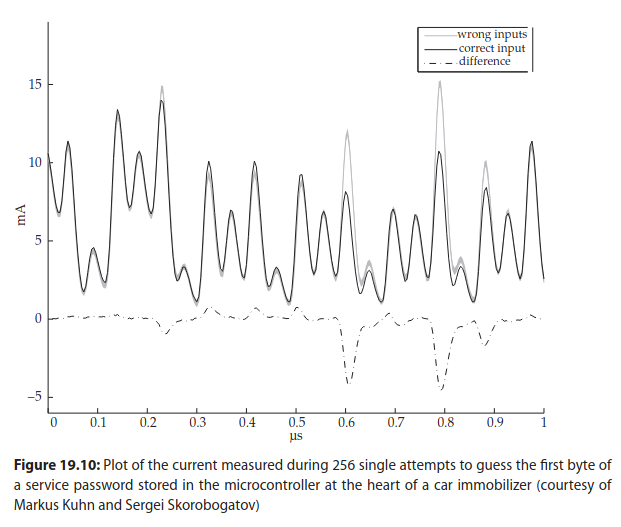

From Ross Anderson, *Security Engineering, Third Edition*

### not just timing — radio frequency

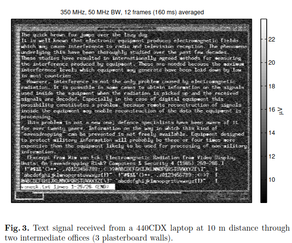

From Kuhn, ‘‘Electromagnetic Eavesdropping Risks of Flat-Panel Displays’’ (PET 2004)

### timing and cryptography

- lots of asymmetric cryptography uses big-integer math
- example: multiplying 500+ bit numbers together
- how do you implement that?

### big integer multiplication

- say we have two 64-bit integers $x$, $y$
  - and want to 128-bit product, but our multiply instruction only does 64-bit products
- one way to multiply:
- divide $x$, $y$ into 32-bit parts: $x=x_1\cdot2^{32}+x_0$ and $y=y_1\cdot2^{32}+y_0$
- then $xy = x_1y_12^{64}+x_1y_0\cdot2^{32}+x_0y_1\cdot2^{32}+x_0y_0$
- can extend this idea to arbitrarily large numbers
- *number of smaller multiplies depends on size of numbers!*

### big integers and cryptography

- naive multiplication idea:
  - number of steps depends on size of numbers
- problem: sometimes the value of the number is a secret
  - e.g. part of the private key
- oops! revealed through timing

### big integer timing attacks in practice (1)

- early versions of OpenSSL (TLS implementation) had timing attack
  - Brumley and Boneh, ‘‘Remote Timing Attacks are Practical’’ (Usenix Security ’03)
- attacker could figure out bits of private key from timing
- why? variable-time multiplication and modulus operations
  - got faster/slower depending on how input was related to private key
  - e.g. detect when attacker-value MOD private key part is close to `0`

### big integer timing attacks in practice (2)

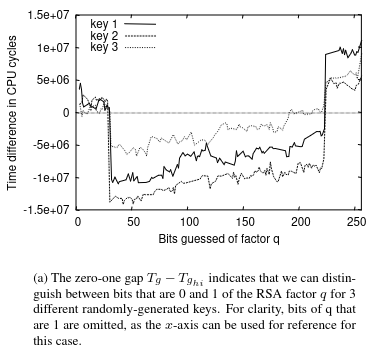

Figure 3a from Brumley and Boneh, ‘‘Remote Timing Attacks are Practical’’

### browsers and website leakage

- web browsers run code from untrusted webpages
- one goal: can’t tell what other webpages you visit

### some webpage leakage (1)

[figure not shown]

- convenient feature 1: browser marks visited links

```
<script>
var the_color = window.getComputedStyle(
    document.querySelector('a[href=~"foo.com"]')
).color
if (the_color == ...) { ... }
</script>
```

- convenient feature 2: scripts can query current color of something

### some webpage leakage (1)

[figure not shown]

- convenient feature 1: browser marks visited links

```
<script>
var the_color = window.getComputedStyle(
    document.querySelector('a[href=~"foo.com"]')
).color
if (the_color == ...) { ... }
</script>
```

- convenient feature 2: scripts can query current color of something
  - fix 1: getComputedStyle lies about the color
  - fix 2: limited styling options for visited links

### some webpage leakage (2)

- one idea: script in webpage times loop that writes big array
- variation in timing depends on *other things running on machine*

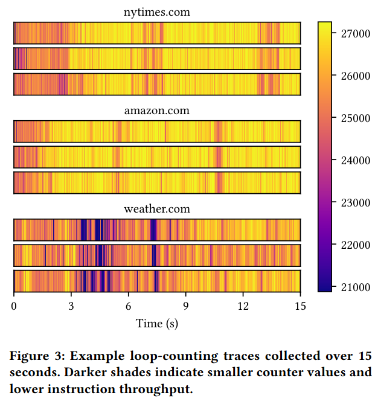

turns out, other webpages create distinct ``signatures’’

Figure from Cook et al, ``There’s Always a Bigger Fish: Clarifying Analysis of a Machine-Learning-Assisted Side-Channel Attack’’ (ISCA ’22)

### side channels

- observing machine operation, indirectly
- common types of indirect observations
  - timing
  - power draw
  - electromagnetic radiation
- side channels can be security and privacy issues
  - often used to reveal internal/secret state

### our focus

- we’re going to focus on timing-related leaks…
- and interaction with attacker input/processor design
- discovery: lots of cases where features that make code/processors fast  
  let attackers learn much more than they should through timing

### inferring cache accesses (1)

- suppose I time accesses to array of chars:
  - reading array[0]: 3 cycles
  - reading array[64]: 4 cycles
  - reading array[128]: 4 cycles
  - reading array[192]: 20 cycles
  - reading array[256]: 4 cycles
  - reading array[288]: 4 cycles
  - …
- what could cause this difference?
  - array[192] not in some cache, but others were

### inferring cache accesses (2)

some psuedocode:

```c
char array[CACHE_SIZE];
AccessAllOf(array);
*other_address += 1;
TimeAccessingArray();
```

- suppose during these accesses I discover that `array[128]` is slower to access
- probably because `*other_address` loaded into cache + evicted it
- what do we know about `other_address`? (select all that apply)

| A. same cache tag | B. same cache index | C. same cache offset |
| --- | --- | --- |
| D. diff. cache tag | E. diff. cache index | F. diff. cache offset |

### some complications

- caches often use physical, not virtual addresses
  - (and need to know about physical address to compare index bits)
  - (but can infer physical addresses with measurements/asking OS)
  - (often OS allocates contiguous physical addresses esp. w/‘large pages’)
- storing/processing timings evicts things in the cache
  - (but can compare timing with/without access of interest to check this)
- processor ‘‘pre-fetching’’ may load things into cache before access is timed
  - (but can arrange accesses to avoid triggering prefetcher  
    and make sure to measure with memory barriers)
- some L3 caches use a simple hash function to select index instead of index bits

### exercise: inferring cache accesses (1)

```c
char *array;
array = AllocateAlignedPhysicalMemory(CACHE_SIZE);
LoadIntoCache(array, CACHE_SIZE);
if (mystery) {
    *pointer += 1;
}
if (TimeAccessTo(&array[index]) > THRESHOLD) {
    /* pointer accessed */
}
```

- suppose `pointer` is `0x1000188`
- and cache (of interest) is direct-mapped, 32768 ($2^{15}$) byte, 64-byte blocks
- what array index should we check?

### solution

```c
array = AllocateAlignedPhysicalMemory(CACHE_SIZE);
LoadIntoCache(array, CACHE_SIZE);
if (mystery) { *pointer = 1; }
if (TimeAccessTo(&array[index]) > THRESHOLD) { /* pointer accessed */ }
```

- $2^{15}$ byte direct mapped cache, $64=2^{6}$ byte blocks
- 9 index bits, 6 offset bits
- `0x1000188`: `… 0000 0001 1000 1000`
- `array[0]` starts at multiple of cache size — index 0, offset 0
- to get index 6, offset 0 array[`0b1 1000 0000`] = array[`0x180`]

### aside

```c
array = AllocateAlignedPhysicalMemory(CACHE_SIZE);
LoadIntoCache(array, CACHE_SIZE);
if (mystery) { *pointer += 1; }
if (TimeAccessTo(&array[index]) > THRESHOLD) {
    /* pointer accessed */
}
```

- will this detect when pointer accessed? yes
- will this detect if mystery is true? not quite
- … because branch prediction could started cache access

### exercise: inferring cache accesses (2)

```c
char *other_array = ...;
char *array;
array = AllocateAlignedPhysicalMemory(CACHE_SIZE);
LoadIntoCache(array, CACHE_SIZE);
other_array[mystery] += 1;
for (int i = 0; i < CACHE_SIZE; i += BLOCK_SIZE) {
    if (TimeAccessTo(&array[i]) > THRESHOLD) {
        /* found something interesting */
    }
}
```

- other_array at 0x200400, and interesting index is i=0x800, then what was mystery?

### solution

```c
array = AllocateAlignedPhysicalMemory(CACHE_SIZE);
LoadIntoCache(array, CACHE_SIZE);
other_array[mystery] += 1;
for (int i = 0; i < CACHE_SIZE; i += BLOCK_SIZE) {
    if (TimeAccessTo(&array[i]) > THRESHOLD) { ... }
}
```

- at i=0x800: `… 0000 1000 0000 0000` (cache index = 0x20)
- other_array at `0x200400`
- Q: `0x200400 + X` has cache index 0x20?

| `0x200400` |  | …`0`*`000 0100 00`*`00 0000` |
| --- | --- | --- |
| $+$ X | $+$ | …`0`*`000 0100 00`*`00 0000` |
| `0x200400` + X |  | …`?`*`000 1000 00`*`00 0000` |

### exercise: inferring cache accesses (2)

```c
char *array;
posix_memalign(&array, CACHE_SIZE, CACHE_SIZE);
LoadIntoCache(array, CACHE_SIZE);
if (mystery) {
    *pointer = 1;
}
if (TimeAccessTo(&array[index1]) > THRESHOLD ||
    TimeAccessTo(&array[index2]) > THRESHOLD) {
    /* pointer accessed */
}
```

- pointer is 0x1000188
- cache is 2-way, 32768 ($2^{15}$) byte, 64-byte blocks, ???? replacement
- what array indexes should we check?

### reading a value — general pattern

```c
char *array;
posix_memalign(&array, CACHE_SIZE, CACHE_SIZE);
AccessAllOf(array);
other_array[mystery] += 1;
for (int i = 0; i < CACHE_SIZE; i += BLOCK_SIZE) {
    if (CheckIfSlowToAccess(&array[i])) {
        ...
    }
}
```

- previous idea: learn bits of mystery that correspond to index bits
  - compute index bits of other_array + mystery as function of mystery
  - see how it matches index bits of array + i

### reading a value — simpler case

```c
char *array;
posix_memalign(&array, CACHE_SIZE, CACHE_SIZE);
AccessAllOf(array);
other_array[mystery * BLOCK_SIZE] += 1;
for (int i = 0; i < CACHE_SIZE; i += BLOCK_SIZE) {
    if (CheckIfSlowToAccess(&array[i])) {
        ...
    }
}
```

- if other_array is char* and starts at multiple of cache size
- and `array[0x6*BLOCK_SIZE]` is slow to access
- mystery == 0x6 + K * SET_COUNT

### PRIME+PROBE

- name in literature: PRIME + PROBE
- PRIME: fill cache (or part of it) with values
- do thing that uses cache
- PROBE: access those values again and see if it’s slow
- (one of several ways to measure how cache is used)
- coined in attacks on AES encryption

### example: AES (1)

- from Osvik, Shamir, and Tromer, ‘‘Cache Attacks and Countermeasures: the Case of AES’’ (2004)
- early AES implementation used lookup tables
- goal: detect index into lookup table
  - index depended on key + data being encrypted
- tricks they did to make this work
  - vary data being encrypted
  - subtract average time to look for what changes
  - lots of measurements

### example: AES (2)

from Osvik, Shamir, and Tromer, ‘‘Cache Attacks and Countermeasures: the Case of AES’’ (2004)

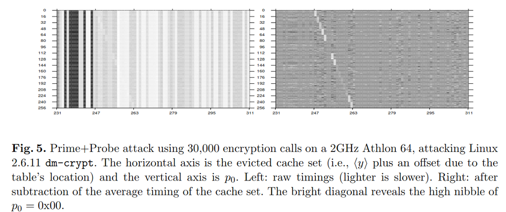

### revisiting an earlier example (1)

```c
char *array;
posix_memalign(&array, CACHE_SIZE, CACHE_SIZE);
LoadIntoCache(array, CACHE_SIZE);
if (mystery) {
    *pointer += 1;
}
if (TimeAccessTo(&array[index]) > THRESHOLD) {
    /* pointer accessed */
}
```

- what if mystery is false *but* branch mispredicted?

### revisiting an earlier example (2)

[figure not shown]

### avoiding/triggering this problem

```
if (... /*something false*/) {
    access *pointer;
}
```

- what can we do to make access more/less likely to happen?

### reading a value without really reading it

```c
char *array;
posix_memalign(&array, CACHE_SIZE, CACHE_SIZE);
AccessAllOf(array);
if (something false) {
    other_array[mystery * BLOCK_SIZE] += 1;
}
for (int i = 0; i < CACHE_SIZE; i += BLOCK_SIZE) {
    if (CheckIfSlowToAccess(&array[i])) {
        ...
    }
}
```

- if branch mispredicted, cache access may *still happen*
- so can find the value of `mystery` despite `if`

### seeing past a segfault? (1)

```c
Prime();
if (... /*something false*/) {
    triggerSegfault();
    Use(*pointer);
}
Probe();
```

- could cache access for `*pointer` still happen?
- yes, if:
  - branch for if statement mispredicted, and
  - `*pointer` starts before segfault detected

### seeing past a segfault? (2)

- operations in virtual memory lookup:
  - translate virtual to physical address
  - check if access is permitted by permission bits
- Intel processors: looks like these were separate steps, so…

```
Prime();
if (something false) {
    int value = ReadMemoryMarkedNonReadableInPageTable();
    access other_array[value * ...];
}
Probe();
```

### Meltdown

from Lipp et al, ‘‘Meltdown: Reading Kernel Memory from User Space’’

```
    // %rcx = kernel address
    // %rbx = array to load from to cause eviction
    xor %rax, %rax      // rax <- 0
retry:
    // rax <- memory[kernel address] (segfaults)
    // but check for segfault done out-of-order on Intel at time
    movb (%rcx), %al
    // rax <- memory[kernel address] * 4096 \[speculated]
    shl $0xC, %rax
    jz retry            // not-taken branch
    // access array[memory[kernel address] * 4096]
    mov (%rbx, %rax), %rbx
```

space out accessed by 4096  
ensure sepaqrate cache sets and  
avoid triggering prefetcher

repeat access if zero  
apparently value of zero speculatively read  
when real value not yet available

acesss cache to allow measurement in later  
in paper with FLUSH+RELOAD instead of PRIME+PROBE

segfault actually happens eventually  
option 1: okay, just start a new process each time  
option 2: suppress segfault  
(paper used (obscure) transactional memory support,  
conceptually, could have used mispredicted branch instead)

### Meltdown fix

- HW: permissions check done with/before physical address lookup
  - was already done by AMD, ARM apparently?
  - now done by Intel
- SW: separate page tables for kernel and user space
  - don’t have sensitive kernel memory pointed to by page table  
    when user-mode code running
  - unfortunate performance problem
  - exceptions start with code that switches page tables

### Spectre

- Meltdown: address translation without permissions check
- seems relatively easy to fix in hardware
- but idea of leaks from speculative execution has much harder to fix attacks…

### reading a value without really reading it

```c
char *array;
posix_memalign(&array, CACHE_SIZE, CACHE_SIZE);
AccessAllOf(array);
if (something false) {
    other_array[mystery * BLOCK_SIZE] += 1;
}
for (int i = 0; i < CACHE_SIZE; i += BLOCK_SIZE) {
    if (CheckIfSlowToAccess(&array[i])) {
        ...
    }
}
```

- if branch mispredicted, cache access may *still happen*
- so can find the value of `mystery` despite `if`

### mistraining branch predictor?

```c
if (something) {
    CodeToRunSpeculatively()
}
```

- useful for attacks:  
  have ‘something’ be false, but predicted as true
- one way: run lots of times with something true then do actually run with something false
- another way: learn how branch prediction caches work, run code that fills in caches in known way

### reading a value — general pattern

```c
char *array;
posix_memalign(&array, CACHE_SIZE, CACHE_SIZE);
AccessAllOf(array);
other_array[mystery] += 1;
for (int i = 0; i < CACHE_SIZE; i += BLOCK_SIZE) {
    if (CheckIfSlowToAccess(&array[i])) {
        ...
    }
}
```

- previous idea: learn bits of mystery that correspond to index bits
  - compute index bits of other_array + mystery as function of mystery
  - see how it matches index bits of array + i

### reading a value — simpler case

```c
char *array;
posix_memalign(&array, CACHE_SIZE, CACHE_SIZE);
AccessAllOf(array);
other_array[mystery * BLOCK_SIZE] += 1;
for (int i = 0; i < CACHE_SIZE; i += BLOCK_SIZE) {
    if (CheckIfSlowToAccess(&array[i])) {
        ...
    }
}
```

- if other_array is char* and starts at multiple of cache size
- and `array[0x6*BLOCK_SIZE]` is slow to access
- mystery == 0x6 + K * SET_COUNT

### reading a value — * X * BLOCK_SIZE

```c
char *array;
posix_memalign(&array, CACHE_SIZE, CACHE_SIZE);
AccessAllOf(array);
other_array[mystery * 8 * BLOCK_SIZE] += 1;
for (int i = 0; i < CACHE_SIZE; i += BLOCK_SIZE) {
    if (CheckIfSlowToAccess(&array[i])) {
        ...
    }
}
```

- if other_array is char* and starts at multiple of cache size
- and `array[0x100*BLOCK_SIZE]` is slow to access
- mystery * 8 = 0x100 + K * SET_COUNT
- mystery = 32 + K * SET_COUNT / 8

### contrived(?) vulnerable code (1)

- suppose this C code is run with extra privileges
  - (e.g. in system call handler, library called from JavaScript in webpage, etc.)
- assume `x` chosen by attacker
- (example from original Spectre paper)

```c
if (x < array1_size)
        y = array2[array1[x] * 4096];
```

### the out-of-bounds access (1)

```c
char array1[...];
...
int secret;
...
y = array2[array1[x] * 4096];
```

- suppose array1 is at `0x1000000` and
- secret is at `0x103F0003`;
- what x do we choose to make `array1[x]` access first byte of secret?

### the out-of-bounds access (2)

```c
unsigned char array1[...];
...
int secret;
...
y = array2[array1[x] * 4096];
```

- suppose our cache has 64-byte blocks and 8192 sets
- and `array2[0]` is char stored in cache set 0
- if the above evicts something in cache set 128,  
  then what do we know about `array1[x]`?

### the out of bounds access (2) soln

- array2[array1[x] * 4096] accesses set with index =  
  (array1[x] * 4096 / BLOCK_SIZE mod 8192)
  - using division + modulus to extract index bits
- know that set number is 128 from probing
- array1[x] * 64 = 128 (mod 8192)
- $\rightarrow$ array1[x] * 64 = 128 + 8192 * K
- array1[x] = 2 + 128 * K

### exploit with contrived(?) code

```c
/* in kernel: */
int systemCallHandler(int x) {
    if (x < array1_size)
        y = array2[array1[x] * 4096];
    return y;
}
```

```c
/* exploiting pseudocode */
    /* step 1: mistrain branch predictor */
for (a lot) {
    systemCallHandler(0 /* less than array1_size */);
}
    /* step 2: evict from cache using misprediction */
Prime();
systemCallHandler((targetAddress - array1Address) / A1ElemSize);
int evictedSet = ProbeAndFindEviction();
int targetValue = (evictedSet - array2StartSet) / setsPer4KA2Elem;
```

### really contrived?

```c
char *array1; char *array2;
if (x < array1_size)
    y = array2[array1[x] * 4096];
```

- times 4096 shifts so we can get lower bits of target value
  - so all bits effect what cache block is used

```c
int *array1; int *array2;
if (x < array1_size)
    y = array2[array1[x]];
```

- will still get *upper* bits of array1[x] (can tell from cache set)
  - still likely to be sensitive data

### bounds check in kernel

```
void SomeSystemCallHandler(int index) {
    if (index > some_table_size)
        return ERROR;
    int kind = table[index];
    switch (other_table[kind].foo) {
        ...
    }
}
```

```
if (x < array1_size) {
    y = array2[array1[x]];
}
```

### generalizing exploit

- limited in what address we can learn about based on how big entries in tables are
  - but can combine multiple Spectre-type exploits
  - only need one secret value leaked
- need to adjust calculations to actual addresses / array element sizes / etc.

### privilege levels?

- vulnerable code runs with higher privileges
- so far: higher privileges = kernel mode
- but other common cases of higher privileges
- example: scripts in web browsers

### JavaScript

- JavaScript: scripts in webpages
- not supposed to be able to read arbitrary memory, but…
- can access arrays to examine caches
- and could take advantage of some browser function being vulnerable
- or — doesn’t even need browser to supply vulnerable code itself!

### just-in-time compilation?

- for performance, compiled to machine code, run in browser
- not supposed to be access arbitrary browser memory
- example JavaScript code from paper:

```javascript
if (index < simpleByteArray.length) {
    index = simpleByteArray[index | 0];
    index = (((index * 4096)|0) & (32*1024*1024-1))|0;
    localJunk ˆ= probeTable[index|0]|0;
}
```

- web page runs a lot to train branch predictor
- then does run with out-of-bounds index
- examines what’s evicted by probeTable access

### supplying own attack code?

- JavaScript: could supply own attack code
- turns out also possible with kernel mode scenario
- trick: don’t need to *actually run* code for real
- … just need branch predictor to fetch it  
  so it gets partially executed speculatively

### other misprediction

- so far: talking about mispredicting direction of branch
- what about mispredicting target of branch in, e.g.:

```
// possibly from C code like:
//   (*function_pointer)();
jmp *%rax

// possibly from C code like:
//      switch(rcx) { ... }
jmp *(%rax,%rcx,8)
```

### an idea for predicting indirect jumps

for jmps like `jmp *%rax` predict target with cache:

| bottom 12 bits of jmp address | last seen target |
| --- | --- |
| 0x0–0x7 | 0x200000 |
| 0x8–0xF | 0x440004 |
| 0x10-0x18 | 0x4CD894 |
| 0x18-0x20 | 0x510194 |
| 0x20-0x28 | 0x4FF194 |
| … | … |
| 0xFF8–0xFFF | 0x3F8403 |

- Intel Haswell CPU did something similar to this
  - uses Hash(bits of last several jumps), not just last jmp

### using mispredicted jump

- 1: find some kernel function with `jmp *%rax`
- 2: mistrain branch target predictor for it to jump to chosen code
  - use code at address that conflicts in ‘‘recent jumps cache’’
  - since only bottom bits are used, can set this up in user memory
- 3: have chosen code be attack code (e.g. array access)
  - either write special code OR
  - find suitable instructions (e.g. array access) in existing kernel code
- 4: run the kernel function

### Spectre variants

- showed Spectre variant 1 (array bounds), 2 (indirect jump)
  - from original paper
- other possible variations:
  - could cause other things to be mispredicted
    - prediction of where functions return to?
    - values instead of which code is executed?
  - could use side-channel other than data cache changes
    - instruction cache
    - cache of pending stores not yet committed
    - contention for resources on multi-threaded CPU core
    - branch prediction changes
    - …

### some Linux kernel mitigations (1)

```
mov x, %r8
mov size, %r9
cmp %r9, %r8
sbb %rax, %rax  // sbb = subtract with borrow
    // either 0 or -1
```

### some Linux kernel mitigations (2)

- for indirect branches:
- with hardware help:
  - separate indirect (computed) branch prediction for kernel v user mode
  - other branch predictor changes to isolate better
- without hardware help:
  - transform `jmp *(%rax)`, etc. into code that  
    will only predicted to jump to safe locations  
    (by writing assembly very carefully)

### only safe prediction

- as replacement for `jmp *%rax`
- code from Intel’s ‘‘Retpoline: A Branch Target Injection Mitigation’’

```
        call load_label
    capture_ret_spec:    /* <-- want prediction to go here */
        pause
        lfence
        jmp capture_ret_spec
    load_label:
        mov %rax, (%rsp)
        ret
```

### not just BLOCK_SIZE

```c
char *array, *other_array;
// PRIME
posix_memalign(&array, CACHE_SIZE, CACHE_SIZE);
AccessAllOf(array);
// (some code we don't control)
other_array[mystery * N] += 1;  // previously: * BLOCK_SIZE
// PROBE
for (int i = 0; i < CACHE_SIZE; i += BLOCK_SIZE) {
    if (CheckIfSlowToAccess(&array[i])) {
    ...
    }
}
```

- 64KB ($2^{16}$B) direct-mapped cache with 64B blocks
- array[0x800] slow to access?
- other_array at `0x4000000` (index 0, offset 0)
- value of `mystery` if N = 1? N = 32 * 64?

### solution (N=1)

$$\begin{align*}
\left\lfloor\text{mystery} * N / \text{BLOCK_SIZE}\right\rfloor~\text{mod}~1024 & = & 32 \\
\left\lfloor\text{mystery} * N / \text{BLOCK_SIZE}\right\rfloor & = & 32 + 1024K \\
\end{align*}$$
let offset be some number in [0,BLOCK_SIZE):
$$\begin{align*}
\text{mystery} * N & = & \text{BLOCK_SIZE}\times(32+1024Z) + \text{offset}\\
\text{mystery} & = & \text{BLOCK_SIZE}\times(32+1024Z) + N\times\text{offset} \\
\text{mystery} & = & 64\times(32+1024Z)+N\times\text{offset} \\
\end{align*}$$
N=1: mystery = $2048$, $2049$, $2050$, …, $2048+63$, $64\cdot1024+2048$, $64\cdot1024+2048+1$, …

### exercise (N=`32*64`)

- what if N = 32*64
- recall: other_array[0] is set 0, offset 0
- other_array[mystery * N] is set 32
- possible values of mystery?

$$\begin{align*}
\text{mystery}\cdot 32\cdot 64 & = & 64(32+1024Z) + \text{offset} \\
& = & 64\cdot32 + 65536Z + \text{offset}\\
\text{mystery} & = & 1 + \frac{65536}{64\cdot32}Z + \frac{\text{offset}}{64\cdot32} = 1+32Z \\
\end{align*}$$

### alternate view

- learn index bits of mystery * N
- this example: bits 6–15
- N = 1, bits 6–15 of mystery
- N = 64, bits 0–9 of mystery
- N = 32*64 ($2^{11}$), bits 0–4 of mystery

### exercise

```c
char *array;
// PRIME
posix_memalign(&array, CACHE_SIZE, CACHE_SIZE);
AccessAllOf(array);
// (some code we don't control)
other_array[mystery * BLOCK_SIZE] += 1;
// PROBE
for (int i = 0; i < CACHE_SIZE; i += BLOCK_SIZE) {
    if (CheckIfSlowToAccess(&array[i])) {
    ...
    }
}
```

- 64KB ($2^{16}$B) direct-mapped cache with 64B blocks
- array[0x800] slow to access;
- other_array at `0x4000000`
- value of `mystery`?

### exercise solution (1)

- NUM_SETS = 64KB/64B = 1K (1024) sets
- array[0x800] has cache index `0x800`/BLOCK_SIZE mod NUM_SETS
  - = cache index 32
- know `other_array[mystery * BLOCK_SIZE]` had same index
- `other_array[0]` at cache index 0
  - (0x4000000 / BLOCK_SIZE) mod NUM_SETS = 0

### exercise solution (2)

- recall have found:
  - `other_array[0]` at index 0;
  - `other_array[mystery*BLOCK_SIZE]` has index 32 (same as `array[0x800]`)
- `other_array[X]` at cache index (0 + X/BLOCK_SIZE mod NUM_SETS)
  - advanced by X/BLOCK_SIZE blocks
  - wrapping around after NUM_SETS blocks
- X = mystery * BLOCK_SIZE
- 32 = 0 + mystery mod NUM_SETS
- mystery = 32 or 32 $\pm$ 1024 or 32 $\pm$ 1024 $\times$ 2 or etc.

### variation: associative cache

```
char *array;
// PRIME
posix_memalign(&array, CACHE_SIZE, CACHE_SIZE);
AccessAllOf(array);
// (some code we don't control)
other_array[mystery * BLOCK_SIZE] += 1;
// PROBE
for (int i = 0; i < CACHE_SIZE; i += BLOCK_SIZE) {
    if (CheckIfSlowToAccess(&array[i])) { ...  }
}
```

- suppose 2-way 64KB cache instead of direct-mapped
- NUM_SETS = 64KB/2/64B = 512 sets
- array[0x800] still has cache index 32 (still)
- but now mystery can be $32$ or $32+512$ or $32+512\cdot2$ or …

### variation: associative cache (2)

```
char *array;
// PRIME
posix_memalign(&array, CACHE_SIZE, CACHE_SIZE);
AccessAllOf(array);
// (some code we don't control)
other_array[mystery * BLOCK_SIZE] += 1;
// PROBE
for (int i = 0; i < CACHE_SIZE; i += BLOCK_SIZE) {
    if (CheckIfSlowToAccess(&array[i])) { ...  }
}
```

- suppose 2-way 64KB cache w/ 64B and *array[0x8800]* is slow
- 0x8800/BLOCK_SIZE = 544 = 512 + 32
- since 512 sets total, still set index 32
- mystery still $32$ or $32+512$ or $32+512\cdot2$ or …

### exercise

- if 4-way 64KB cache w/64B blocks and something from cache set 32 evicted,  
  then where could slow access be?
  - recall: 2-way cache: i=0x800, i=0x8800
- A. i=0x400, i=0x800, i=0x8400, i=0x8800
- B. i=0x800, i=0x8800, i=0x10800, i=0x18800
- C. i=0x800, i=0x4800, i=0x8800, i=0xc800
- D. i=0x800, i=0x4800, i=0x8800, i=0x10800
- E. something else

### EVICT+RELOAD

- PRIME+PROBE: fill cache, detect eviction
- alternate idea EVICT+RELOAD:

```
unsigned char *probe_array;
posix_memalign(&probe_array, CACHE_SIZE, CACHE_SIZE);
access OTHER things to evict all of probe_array
if (something false) {
    read probe_array\[mystery * BLOCK_SIZE];
}
check which value from probe_array is faster
```

- requires code to access something you can access
- but often easier to setup/more reliable than PRIME+PROBE

### into exploit: Meltdown

```
uint8_t* probe_array = new uint8_t[256 * 4096];
// ... Make sure probe_array is not cached
uint8_t kernel_memory_val = *(uint8_t*)(kernel_address);
uint64_t final_kernel_memory = kernel_memory_val * 4096;
uint8_t dummy = probe_array[final_kernel_memory];
// ... catch page fault
// ... in signal handler, determine which of 256 slots in probe_array is cached
```